# Assignment 5A: Airline Delays

Mohd Afwan Shaikh

2026-10-02

# Introduction and Approach

For this assignment, I analyzed airline arrival data for Alaska Airlines and AM West across five destinations: Los Angeles, Phoenix, San Diego, San Francisco, and Seattle.

I recreated the provided data in a CSV file using the original wide format and imported it into R. I checked the dataset for missing values and used dplyr and tidyr to transform it from wide format to long format.

I then calculated the percentage of flights that were delayed and on time for each airline. I compared the airlines’ overall performance and examined their delay percentages separately across all five destinations using tables and visualizations.

Finally, I investigated the difference between the overall and city-by-city comparisons to understand how the distribution of flights across destinations affected the results.

## Data Collection and Preparation

I recreated the airline arrival data from the assignment and saved it as a CSV file. The original dataset contains four rows representing the two arrival statuses for each airline and five columns containing destination-specific flight counts.

**Data source:** The airline arrival-delay table provided in the DATA 607 *Tidying and Transforming Data* assignment, originally attributed to *Numbersense* by Kaiser Fung (McGraw-Hill, 2013).

The dataset includes 20 flight counts covering two airlines, two arrival statuses, and five destinations. All 20 reported counts were present in the recreated CSV, so no missing values needed to be filled.

```r
airline_data <- data.frame(
  Airline = c("Alaska", "Alaska", "AM West", "AM West"),
  Arrival = c("On Time", "Delayed", "On Time", "Delayed"),
  Los_Angeles = c(497, 62, 694, 117),
  Phoenix = c(221, 12, 4840, 415),
  San_Diego = c(212, 20, 383, 65),
  San_Francisco = c(503, 102, 320, 129),
  Seattle = c(1841, 305, 201, 61)
)

write.csv(
  airline_data,
  "airline_delays.csv",
  row.names = FALSE
)

print(airline_data)
```

```
##   Airline Arrival Los_Angeles Phoenix San_Diego San_Francisco Seattle
## 1  Alaska On Time         497     221       212           503    1841
## 2  Alaska Delayed          62      12        20           102     305
## 3 AM West On Time         694    4840       383           320     201
## 4 AM West Delayed         117     415        65           129      61
```

```r
airline_data <- read.csv("airline_delays.csv")

head(airline_data)
```

```
##   Airline Arrival Los_Angeles Phoenix San_Diego San_Francisco Seattle
## 1  Alaska On Time         497     221       212           503    1841
## 2  Alaska Delayed          62      12        20           102     305
## 3 AM West On Time         694    4840       383           320     201
## 4 AM West Delayed         117     415        65           129      61
```

```r
dim(airline_data)
```

```
## [1] 4 7
```

```r
colSums(is.na(airline_data))
```

```
##       Airline       Arrival   Los_Angeles       Phoenix     San_Diego
##             0             0             0             0             0
## San_Francisco       Seattle
##             0             0
```

## Checking for Missing Data

I checked the original dataset for missing values before transforming it. All reported flight counts were present, so no values needed to be replaced. If missing values are found in future data, I will investigate them before deciding how to handle them.

```r
missing_before <- colSums(is.na(airline_data))

print(missing_before)
```

```
##       Airline       Arrival   Los_Angeles       Phoenix     San_Diego
##             0             0             0             0             0
## San_Francisco       Seattle
##             0             0
```

```r
sum(is.na(airline_data))
```

```
## [1] 0
```

### Demonstrating Missing-Value Handling

Although the recreated dataset contains no missing flight counts, the following example demonstrates how missing values could be populated when the source confirms that a missing count represents zero flights.

```r
example_data <- airline_data

example_data$Phoenix[1] <- NA

example_data$Phoenix_Filled <- replace_na(
  example_data$Phoenix,
  0
)

print(
  example_data %>%
    select(Airline, Arrival, Phoenix, Phoenix_Filled)
)
```

```
##   Airline Arrival Phoenix Phoenix_Filled
## 1  Alaska On Time      NA              0
## 2  Alaska Delayed      12             12
## 3 AM West On Time    4840           4840
## 4 AM West Delayed     415            415
```

## Data Validation

```r
stopifnot(nrow(airline_data) == 4)
stopifnot(ncol(airline_data) == 7)
stopifnot(sum(is.na(airline_data)) == 0)
stopifnot(all(airline_data[, 3:7] >= 0))

cat("All data validation checks passed.")
```

```
## All data validation checks passed.
```

I validated the dataset by checking that it contained four rows and seven columns, had no missing values, and included no negative flight counts. All validation checks passed.

## Transforming Data from Wide to Long

I used `pivot_longer()` to combine the five destination columns into a single Destination column. This produced a dataset with 20 rows and four columns, making it easier to compare flight counts across airlines and destinations.

```r
airline_long <- airline_data %>%
  pivot_longer(
    cols = -c(Airline, Arrival),
    names_to = "Destination",
    values_to = "Flights"
  ) %>%
  mutate(
    Destination = gsub("_", " ", Destination)
  )

print(airline_long)
```

```
## # A tibble: 20 × 4
##    Airline Arrival Destination   Flights
##    <chr>   <chr>   <chr>           <int>
##  1 Alaska  On Time Los Angeles       497
##  2 Alaska  On Time Phoenix           221
##  3 Alaska  On Time San Diego         212
##  4 Alaska  On Time San Francisco     503
##  5 Alaska  On Time Seattle          1841
##  6 Alaska  Delayed Los Angeles        62
##  7 Alaska  Delayed Phoenix            12
##  8 Alaska  Delayed San Diego          20
##  9 Alaska  Delayed San Francisco     102
## 10 Alaska  Delayed Seattle           305
## 11 AM West On Time Los Angeles       694
## 12 AM West On Time Phoenix          4840
## 13 AM West On Time San Diego         383
## 14 AM West On Time San Francisco     320
## 15 AM West On Time Seattle           201
## 16 AM West Delayed Los Angeles       117
## 17 AM West Delayed Phoenix           415
## 18 AM West Delayed San Diego          65
## 19 AM West Delayed San Francisco     129
## 20 AM West Delayed Seattle            61
```

## Overall Airline Performance

```r
overall_performance <- airline_long %>%
  group_by(Airline, Arrival) %>%
  summarise(
    Flights = sum(Flights),
    .groups = "drop"
  ) %>%
  pivot_wider(
    names_from = Arrival,
    values_from = Flights
  ) %>%
  mutate(
    Total_Flights = `On Time` + Delayed,
    Delay_Percentage = round(Delayed / Total_Flights * 100, 2),
    On_Time_Percentage = round(`On Time` / Total_Flights * 100, 2)
  )

print(overall_performance)
```

```
## # A tibble: 2 × 6
##   Airline Delayed `On Time` Total_Flights Delay_Percentage On_Time_Percentage
##   <chr>     <int>     <int>         <int>            <dbl>              <dbl>
## 1 AM West     787      6438          7225             10.9               89.1
## 2 Alaska      501      3274          3775             13.3               86.7
```

### Overall Delay Percentage

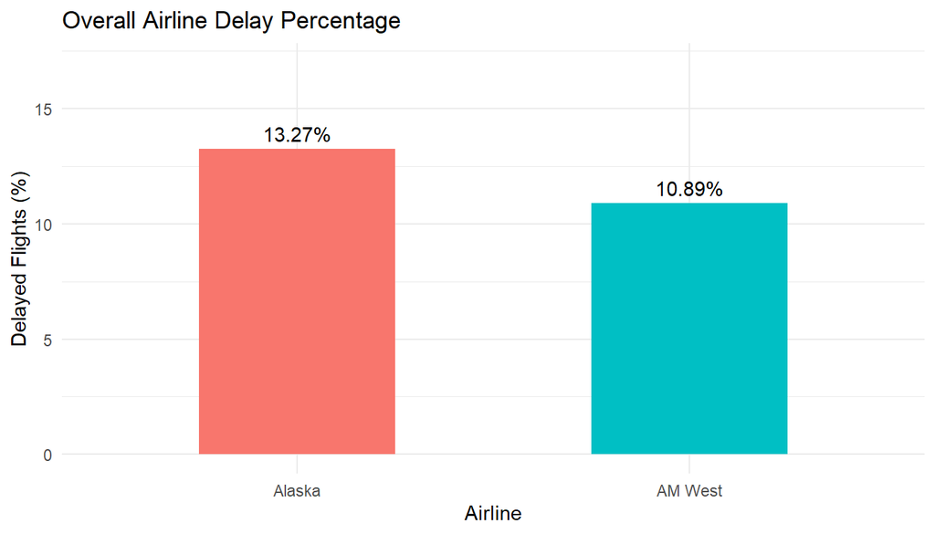

```r
ggplot(
  overall_performance,
  aes(x = Airline, y = Delay_Percentage, fill = Airline)
) +
  geom_col(width = 0.5) +
  geom_text(
    aes(label = paste0(Delay_Percentage, "%")),
    vjust = -0.5
  ) +
  labs(
    title = "Overall Airline Delay Percentage",
    x = "Airline",
    y = "Delayed Flights (%)"
  ) +
  ylim(0, 17) +
  theme_minimal() +
  theme(legend.position = "none")
```

## Airline Performance by Destination

```r
city_performance <- airline_long %>%
  pivot_wider(
    names_from = Arrival,
    values_from = Flights
  ) %>%
  mutate(
    Total_Flights = `On Time` + Delayed,
    Delay_Percentage = round(Delayed / Total_Flights * 100, 2),
    On_Time_Percentage = round(`On Time` / Total_Flights * 100, 2)
  ) %>%
  arrange(Destination, Airline)

print(city_performance)
```

```
## # A tibble: 10 × 7
##    Airline Destination   `On Time` Delayed Total_Flights Delay_Percentage
##    <chr>   <chr>             <int>   <int>         <int>            <dbl>
##  1 AM West Los Angeles         694     117           811            14.4
##  2 Alaska  Los Angeles         497      62           559            11.1
##  3 AM West Phoenix            4840     415          5255             7.9
##  4 Alaska  Phoenix             221      12           233             5.15
##  5 AM West San Diego           383      65           448            14.5
##  6 Alaska  San Diego           212      20           232             8.62
##  7 AM West San Francisco       320     129           449            28.7
##  8 Alaska  San Francisco       503     102           605            16.9
##  9 AM West Seattle             201      61           262            23.3
## 10 Alaska  Seattle            1841     305          2146            14.2
## # ℹ 1 more variable: On_Time_Percentage <dbl>
```

### Delay Percentage by Destination

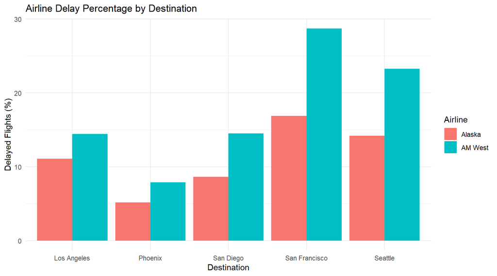

```r
ggplot(
  city_performance,
  aes(
    x = Destination,
    y = Delay_Percentage,
    fill = Airline
  )
) +
  geom_col(position = "dodge") +
  labs(
    title = "Airline Delay Percentage by Destination",
    x = "Destination",
    y = "Delayed Flights (%)",
    fill = "Airline"
  ) +
  theme_minimal()
```

## Flight Distribution by Destination

The number of flights operated by each airline differs significantly across destinations. This helps explain why the overall delay percentages differ from the city-by-city results.

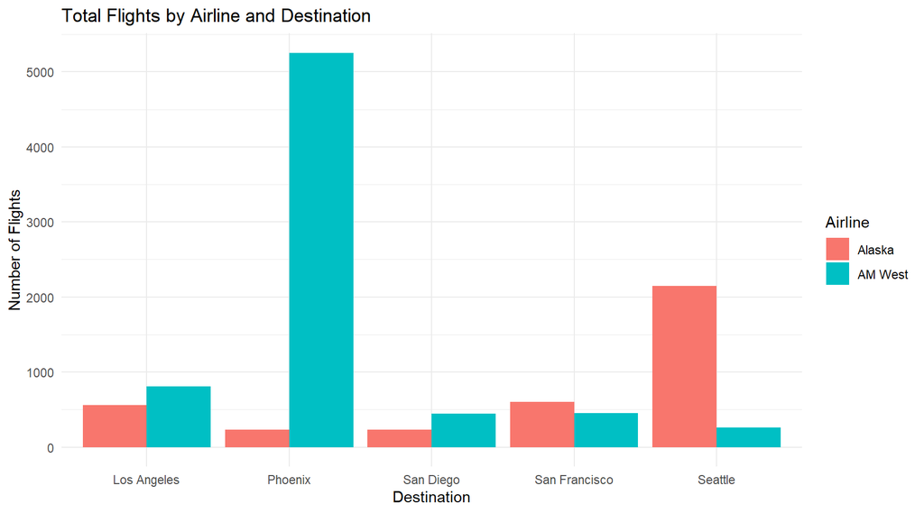

```r
ggplot(
  city_performance,
  aes(x = Destination, y = Total_Flights, fill = Airline)
) +
  geom_col(position = "dodge") +
  labs(
    title = "Total Flights by Airline and Destination",
    x = "Destination",
    y = "Number of Flights",
    fill = "Airline"
  ) +
  theme_minimal()
```

## Percentage of Flights by Destination

The following table shows the percentage of each airline’s total flights operated to each destination.

```r
flight_distribution <- city_performance %>%
  group_by(Airline) %>%
  mutate(
    Flight_Share = round(
      Total_Flights / sum(Total_Flights) * 100, 2
    )
  ) %>%
  ungroup()

print(
  flight_distribution %>%
    select(Airline, Destination, Total_Flights, Flight_Share)
)
```

```
## # A tibble: 10 × 4
##    Airline Destination   Total_Flights Flight_Share
##    <chr>   <chr>                 <int>        <dbl>
##  1 AM West Los Angeles             811        11.2
##  2 Alaska  Los Angeles             559        14.8
##  3 AM West Phoenix                5255        72.7
##  4 Alaska  Phoenix                 233         6.17
##  5 AM West San Diego               448         6.2
##  6 Alaska  San Diego               232         6.15
##  7 AM West San Francisco           449         6.21
##  8 Alaska  San Francisco           605        16.0
##  9 AM West Seattle                 262         3.63
## 10 Alaska  Seattle                2146        56.8
```

### Where Each Airline Operates Most of Its Flights

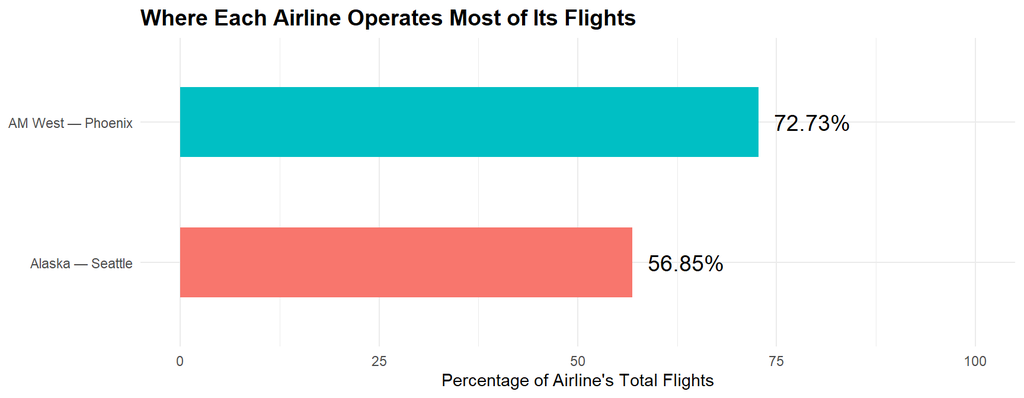

```r
top_destinations <- flight_distribution %>%
  group_by(Airline) %>%
  slice_max(Flight_Share, n = 1, with_ties = FALSE) %>%
  ungroup() %>%
  mutate(
    Label = paste(Airline, Destination, sep = " — ")
  )

ggplot(
  top_destinations,
  aes(x = Flight_Share, y = Label, fill = Airline)
) +
  geom_col(width = 0.5) +
  geom_text(
    aes(label = paste0(Flight_Share, "%")),
    hjust = -0.2,
    size = 5
  ) +
  scale_x_continuous(limits = c(0, 100)) +
  labs(
    title = "Where Each Airline Operates Most of Its Flights",
    x = "Percentage of Airline's Total Flights",
    y = NULL
  ) +
  theme_minimal() +
  theme(
    legend.position = "none",
    plot.title = element_text(face = "bold", size = 14)
  )
```

## Difference in Delay Rates by Destination

```r
delay_difference <- city_performance %>%
  select(Airline, Destination, Delay_Percentage) %>%
  pivot_wider(
    names_from = Airline,
    values_from = Delay_Percentage
  ) %>%
  mutate(
    Difference = `AM West` - Alaska
  )

print(delay_difference)
```

```
## # A tibble: 5 × 4
##   Destination   `AM West` Alaska Difference
##   <chr>             <dbl>  <dbl>      <dbl>
## 1 Los Angeles        14.4  11.1        3.34
## 2 Phoenix             7.9   5.15       2.75
## 3 San Diego          14.5   8.62       5.89
## 4 San Francisco      28.7  16.9       11.9
## 5 Seattle            23.3  14.2        9.07
```

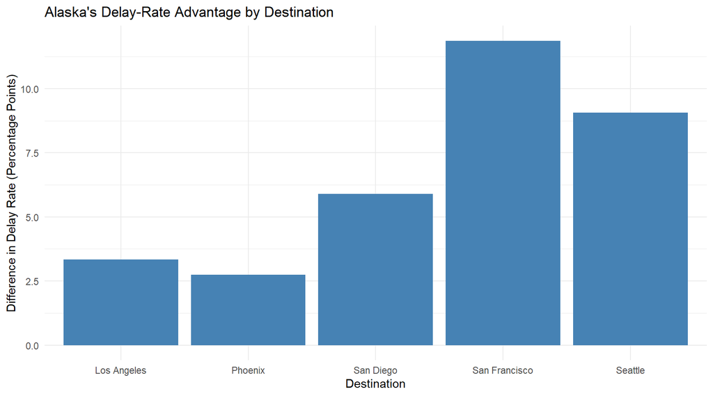

```r
ggplot(
  delay_difference,
  aes(x = Destination, y = Difference)
) +
  geom_col(fill = "steelblue") +
  labs(
    title = "Alaska's Delay-Rate Advantage by Destination",
    x = "Destination",
    y = "Difference in Delay Rate (Percentage Points)"
  ) +
  theme_minimal()
```

## Findings and Discussion

### Overall Airline Performance

AM West had an overall delay rate of 10.89%, compared with 13.27% for Alaska Airlines. Based on the overall percentages alone, AM West appeared to perform better.

### Performance Across the Five Destinations

When I compared the airlines separately across the five destinations, Alaska Airlines had a lower delay percentage in every city. The largest difference was in San Francisco, where Alaska had a delay rate of 16.86%, compared with 28.73% for AM West.

### Explaining the Discrepancy

The difference between the overall and city-by-city comparisons is an example of Simpson’s paradox. Although Alaska Airlines had a lower delay percentage in every destination, AM West had a lower overall delay percentage.

The flight distribution analysis helps explain this reversal. Approximately 72.73% of AM West’s flights were to Phoenix, where both airlines had relatively low delay rates. In comparison, approximately 56.85% of Alaska’s flights were to Seattle, where delays were more common.

Because the two airlines operated different proportions of flights across destinations, the overall comparison was influenced by their destination distributions. This demonstrates why examining percentages within individual groups is important when interpreting aggregated data.

## Conclusion

This analysis showed that AM West had a lower overall delay percentage, while Alaska Airlines had a lower delay percentage in every individual destination. This reversal illustrates Simpson’s paradox.

The results demonstrate that overall percentages can be misleading when groups have different distributions of observations. Comparing the airlines within each destination provided a more complete understanding of their performance.